# Homework 1

# 繳交期限：10/25，6pm

# 1.

請讀入資料：stock = read_csv(“stock.csv”)

資料為2023/12/1~2024/3/7，5個股票的股價，變數為：

- id_name：每檔股票的證券代碼與名稱，如：2330 台積電，表示證券代碼2330，公司名稱為台積電。
- type：open 代表開盤價，close 代表收盤價。
- 2023/12/1：為該天交易價格（剩下日期變數依此類推）。

### 請用`tidyr`提到的`gather`,`spread`,`sperate`等函數指令，將資料整理成下方「tidy」格式（這裡示意圖只秀出前18筆）：

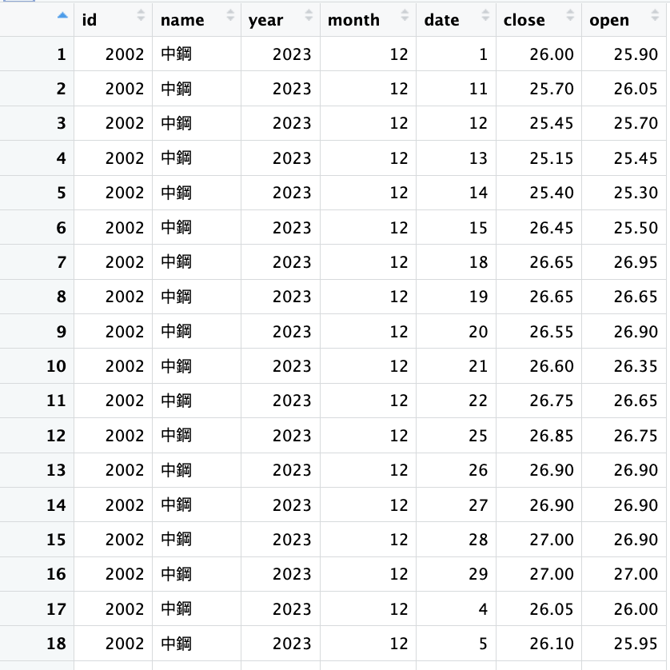

# 2. 電商公司，有三個資料集合：

- `sales.df`：產品銷售狀況（“salesID”銷售紀錄編號，“Store”店家編號， “Product”產品編號，“Client”顧客編號，“UnitPrice”單價，“Quantity”購買數量，“Region”顧客國家 ）
- `client.df`：顧客的個人資料 (“Client”顧客編號，“Age”年紀，“Membership”會員等級， “Gender”性別 )
- `prod.df`：產品的相關資料（“Item” 代號＿產品）

請用`tidyverse`套件裡學到的方法，分析

### 1. `prod.df` 裡將兩個變數，誤紀錄為在同一個column，其將其分開為兩個變數Product（數字部分）及Item（商品部分），取代原`prod.df`。

### 2. 將3個報表合併為`full.table`

### 3. 在`full.table`. 新增一個變數「總消費」為spend = UnitPrice*Quantity

### 4. 在`full.table`將會員等級分組，其中gold和diamond的顧客為一組，其他等級的為一組，針對兩組客戶進行比較介紹（例如平均年紀、性別、國家、消費情況差異等）。

### 5. 在`full.table`針對女性客戶進行分析（例如平均年紀、國家、消費情況等），並對他們在不同產品的「總消費」畫圖分析。